# Natural Language processing of Wikipedia Data (Tata Group)

Rajiv

27 November 2016

NLP

## Step - 1: Selecting a Company

**In here my company of interest will be: Tata Group**

## step - 2: Scraping the Wiki page of the comapny.

We are loading the necessary packages for webscraping and for Basic NLP: *rvest, NLP, openNLP, ggmap, rworldamp*

Scraping the Wiki page of Tata Group.

```r
page = read_html('https://en.wikipedia.org/wiki/Tata_Group')
text = html_text(html_nodes(page,'p'))
text = text[text != ""]
text = gsub("\\[[0-9]]|\\[[0-9][0-9]]|\\[[0-9][0-9][0-9]]","",text)
text = paste(text,collapse = " ")
text = as.String(text)
```

Text that is scraped is also displayed below.

```r
writeLines(text)
```

```
## Tata Group is an Indian multinational conglomerate holding company headquartered in Mumbai, Maharashtra, India. It was founded in 1868 by Jamsetji Tata and gained international recognition after purchasing several global companies. It is India's largest conglomerate and is owned by "Tata Sons", a…
```

## Step - 3: Persons and Locations mentioned in the page

```r
t = Sys.time()
sent_annot = Maxent_Sent_Token_Annotator()
word_annot = Maxent_Word_Token_Annotator()
loc_annot = Maxent_Entity_Annotator(kind = "location")
person_ann <- Maxent_Entity_Annotator(kind = "person")
annot.l1 = NLP::annotate(text, list(sent_annot,word_annot,loc_annot,person_ann))
k <- sapply(annot.l1$features, `[[`, "kind")
coke_locations = text[annot.l1[k == "location"]]
coke_persons = text[annot.l1[k == "person"]]
Sys.time() - t
```

```
## Time difference of 5.676325 secs
```

All the Person names that are mentioned in the page for this company

```r
coke_persons
```

```
## [1] "Pankaj Baliga"   "Thura Shwe Mann" "Ratan Tata"      "Narendra Modi"
```

All Location Names that were mentioned in the page

```r
coke_locations = unique(coke_locations)
coke_locations
```

```
## [1] "India"         "Boston"        "Massachusetts" "Munnar"
## [5] "Burma"         "Pune"          "West Bengal"   "Tanzania"
## [9] "Lake Natron"
```

## Step - 4: Plotting locations on the map

The Locations mentioned in the company page are plotted on a map.

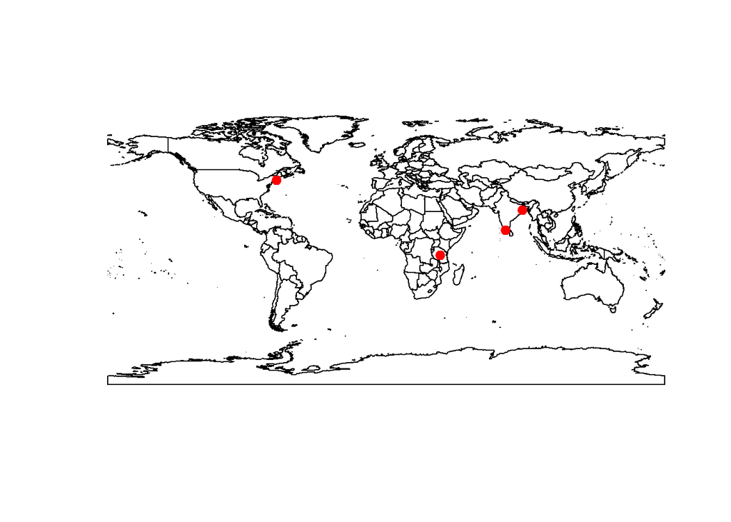

```r
t = Sys.time()
all_places_geocoded <- geocode(coke_locations)
#all_places_geocoded
newmap <- getMap(resolution = "high")
plot(newmap,asp = 1)
points(all_places_geocoded$lon, all_places_geocoded$lat, col = "red", cex = 1.2, pch = 19)
```

```r
Sys.time() - t
```

```
## Time difference of 2.920167 secs
```

## Step - 5: Observations

From my Observations i can see that places like Mumbai, Maharastra, Kerala, Odisha etc.., are not recognized by the system.

Names like Ratan Tata, Narendra Modi etc.., were recognized by the system. But the Founder Jamsetji Tata, ex - ceo Cyrus Misty and many other indian names were not recognized by the NLP system.

Though Tata Group is an well renowened company all over the world, the page dosent seem to contain much information. It gives us only few names and places from the group’s wiki page.